# 4: Assigning farm locations

```r
library(tidyverse)
library(sf)
library(here)
library(qs2)
library(RColorBrewer)
library(purrr)

here("src", "dirs.R") %>% source()
here("src", "functions.R") %>% source()
here("src", "display_globals.R") %>% source()
here("src", "mapping_vars.R") %>% source()
```

# Overview

This document imports data from Clawson et al. (2022) on known and modelled mariculture locations and assigns farms to the species being modelled here. However, there are some challenges to overcome in this process:

- The data from Clawson et al. (2022) is from 2017 and was based on contemporary aquaculture production data, which has increased significantly since then (and possibly changed in relative species production). New aquaculture locations will not be estimated to accomodate for this - instead, each location will likely produce more than is intended. This is because the aim of this study is to examine change in production/feed demand with climate change, not accurately predict current production.
- There are some gaps acknowledged by Clawson et al. (2022), particularly surrounding China’s production locations.
- There is a possibility that any particular country/FAO fishing region will not have enough farms or farms of a specified type to accomodate all of that country’s production. In this case, we will use habitat suitability (temperature range) to place additional farms within that country’s EEZ.

# Get data

**Get mariculture locations data**

```r
aqua_locs <- file.path(prepdata_path, "mariculture_locations_FAO_codes.qs") %>%
    qd_read() %>%
    rename(ISO3_Code = iso3c)
```

**Make sure the mariculture locations data looks right**

```
ℹ Adding new coordinate system, which will replace the existing one.
```

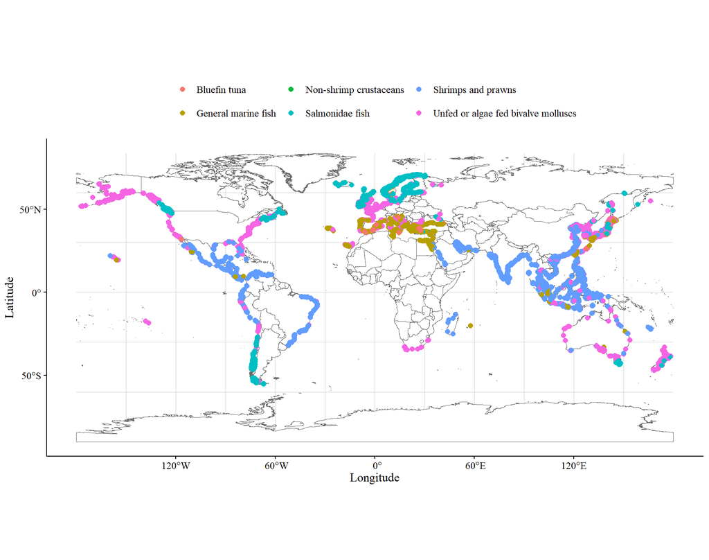

Figure 1: Map of mariculture locations, coloured by species group.

```r
p_bigmap_mercator +
  geom_sf(
    data = aqua_locs,
    aes(color = species_group, geometry = geometry),
    size = 2
  ) +
  coord_sf() +
  prettyplot() +
  theme(legend.position = "top")
```

**Get prepared production data - already filtered by assigned model names**

```r
FAO_aqua <- file.path(prepdata_path, "FAO_with_models_final_production.csv") %>%
    read.csv()

# Get FAO fishing region code keys and add to production data
FAO_code_key <- file.path(prepdata_path, "FAO_code_key.csv") %>%
    read.csv() %>% select(-X)
FAO_aqua <- FAO_aqua %>%
    left_join(FAO_code_key, by = c("fao_fishing_area" = "NAME_EN"))

# Check that none were left blank
# FAO_aqua %>%
#     filter(is.na(F_CODE)) %>%
#     pull(fao_fishing_area) %>%
#     unique()

# Add groups based on the location data groups
FAO_aqua <- FAO_aqua %>%
    mutate(
        location_group = case_when(
            model_name %in% c("tuna") ~ "Bluefin tuna",
            model_name %in% c("rainbow_trout", "atlantic_salmon") ~ "Salmonidae fish",
            model_name %in% c("whiteleg_shrimp", "tiger_prawn") ~ "Shrimps and prawns",
            model_name %in% c("mud_crab") ~ "Non-shrimp crustaceans",
            model_name %in% c("japanese_sea_cucumber", "abalone") ~ "Unfed or algae fed bivalve molluscs",
            TRUE ~ "General marine fish",
        ),
    model_name = as.factor(model_name),
    location_group = as.factor(location_group)
    ) %>%
    select(-c(fao_fishing_area, species_name, environment))

str(FAO_aqua)
```

```
'data.frame':   3005 obs. of  7 variables:
 $ period        : int  2012 2014 2016 2018 2020 2022 2012 2014 2016 2018 ...
 $ value         : num  400 700 800 1000 2875 ...
 $ country       : chr  "Albania" "Albania" "Albania" "Albania" ...
 $ ISO3_Code     : chr  "ALB" "ALB" "ALB" "ALB" ...
 $ model_name    : Factor w/ 18 levels "abalone","atlantic_salmon",..: 4 4 4 4 4 4 15 15 15 15 ...
 $ F_CODE        : int  37 37 37 37 37 37 37 37 37 37 ...
 $ location_group: Factor w/ 6 levels "Bluefin tuna",..: 2 2 2 2 2 2 2 2 2 2 ...
```

Production has increased since 2017 (Figure 2). Since the aquaculture mapping data was based on production data, there will be some additional uncertanties based on this change - however the only real implications will be changes in the ratios of species produced. However, from Figure 2, it looks like the changes aren’t all that drastic.

**Show how production of each mapped group has changed in the last 5 years**

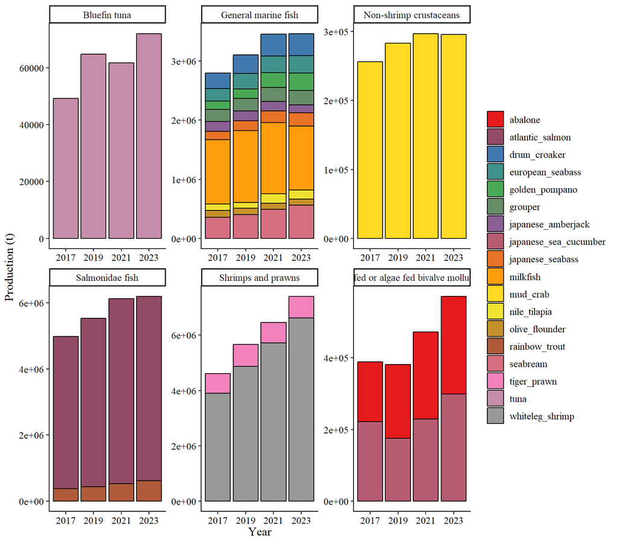

Figure 2: Comparing global production of each `model_name` from 2017 – 2023, split by the groupings present in the aquaculture mapping data.

```r
FAO_aqua %>%
    # I don't know why the years are paired like this in the data but they are - even-numbered years have ~3x the production of odd numbered years
    mutate(period = case_when(
        period %in% 2022:2023 ~ 2023,
        period %in% 2020:2021 ~ 2021,
        period %in% 2018:2019 ~ 2019,
        period %in% 2016:2017 ~ 2017
    )) %>%
    group_by(period, model_name, location_group) %>%
    reframe(total_value = sum(value, na.rm = T)) %>%
    filter(period %in% c(2017:max(FAO_aqua$period))) %>%
    ggplot(aes(
        x = as.factor(period),
        y = total_value,
        fill = model_name
    )) +
    geom_col(colour = "black") +
    facet_wrap(~location_group, scales = "free") +
    scale_fill_manual(
        name = "Model name",
        values = colorRampPalette(brewer.pal(9, "Set1"))(18)
    ) +
    prettyplot() +
    theme(legend.position = "right") +
    labs(
        x = "Year", y = "Production (t)"
    )
```

```r
FAO_aqua_means <- FAO_aqua %>%
    filter(period >= 2017) %>%
    group_by(ISO3_Code, country, F_CODE, location_group, model_name) %>%
    reframe(value = mean(value, na.rm = TRUE)) %>%
    filter(value != 0)

rm(FAO_aqua)
str(FAO_aqua_means)
```

```
tibble [351 × 6] (S3: tbl_df/tbl/data.frame)
 $ ISO3_Code     : chr [1:351] "ALB" "ALB" "ALB" "ARE" ...
 $ country       : chr [1:351] "Albania" "Albania" "Albania" "United Arab Emirates" ...
 $ F_CODE        : int [1:351] 37 37 37 51 51 51 51 51 51 51 ...
 $ location_group: Factor w/ 6 levels "Bluefin tuna",..: 1 2 2 2 2 2 2 2 4 5 ...
 $ model_name    : Factor w/ 18 levels "abalone","atlantic_salmon",..: 17 4 15 4 6 7 12 15 2 18 ...
 $ value         : num [1:351] 96 2166 3521 523 215 ...
```

# Assign locations

For each country and FAO fishing region combination, we follow these steps:

**Check which countries/FAO codes are present in each dataset.**

```r
all_regions_production <- FAO_aqua_means %>%
    distinct(ISO3_Code, F_CODE)

all_regions_locations <- aqua_locs %>%
    distinct(ISO3_Code, F_CODE)

# In production but not locations
in_prod_not_loc <- anti_join(all_regions_production, all_regions_locations, by = c("ISO3_Code", "F_CODE"))

# In locations but not production
in_loc_not_prod <- anti_join(all_regions_locations, all_regions_production, by = c("ISO3_Code", "F_CODE"))

cat(sprintf(
    "In production data but not locations: %d\nIn locations but not production data: %d\n",
    nrow(in_prod_not_loc), nrow(in_loc_not_prod)
))
```

```
In production data but not locations: 46
In locations but not production data: 17
```

Any farmed locations that don’t correspond with any production data will be excluded (they’re likely species not included in the `model_names` chosen). Any production values not included in the farmed locations will be included - farmed locations will be generated for them later.

```r
# Location groups are handled in order, from most specific -> most general (in terms of the number of model names assigned to them)
groups_order <- c(
    "Bluefin tuna",
    "Non-shrimp crustaceans",
    "Salmonidae fish",
    "Shrimps and prawns",
    "Unfed or algae fed bivalve molluscs",
    "General marine fish"
)
```

Each of the following subsections assigns farms for one of these groups, in order. Each subsection gives the following pieces of information:

- `combined_locations_<model>` - a list of the available mapped farms assigned to that model’s production globally.
- `regions_without_assignments_<model>` - a list of the regions (countries x FAO regions) which have production data but have no assigned farms. These will need to be assigned using habitat suitability later.
- `farms_excluded_<model>` - the `farm_ID` values of locations that were mapped for a model but which were not selected for this analysis. If needed these can be called upon for future assignments.

## Bluefin tuna (`tuna`)

**Assign mapped farm locations to bluefin tuna.**

```r
this_group <- groups_order[1]

all_regions_production <- FAO_aqua_means %>%
    filter(location_group == this_group) %>%
    group_by(ISO3_Code, F_CODE) %>%
    group_split()

all_region_locs <- aqua_locs %>%
    filter(species_group == this_group) %>%
    rename(t_per_farm_2017 = tonnes_per_farm) %>%
    st_drop_geometry() %>%
    select(-NAME_EN)

# this_region_prod <- all_regions_production[[4]]

tuna_locations <- map_dfr(
    all_regions_production,
    function(this_region_prod) {
        # Info
        ISO3        <- unique(this_region_prod$ISO3_Code)
        F_CODE      <- unique(this_region_prod$F_CODE)

        this_region_locs <- all_region_locs %>%
            filter(ISO3_Code == ISO3, F_CODE == F_CODE) %>%
            group_by(species_group) %>%
            mutate(prop_species_tonnes = sum(t_per_farm_2017, na.rm = T)) %>%
            ungroup() %>%
            mutate(prop_species_tonnes = t_per_farm_2017/prop_species_tonnes)

        # If there are any locations to be assigned, they are all assigned to tuna (because it's only one model_name)
        if (nrow(this_region_locs) > 0) {
            production_locations <- this_region_prod %>%
                left_join(this_region_locs, by = c("ISO3_Code", "country", "F_CODE", "location_group" = "species_group")) %>%
                mutate(t_per_farm_2023 = prop_species_tonnes * value)
        } else {
            production_locations <- this_region_prod %>%
                mutate(t_per_farm_2017 = NA, farm_ID = NA, prop_species_tonnes  = NA, t_per_farm_2023 = NA)
        }
        return(production_locations)
    },
    .progress = T
)
```

**Show how tuna has been assigned to different regions**

```r
options(width = 120)

# These countries have production values but no locations assigned
tuna_locations %>%
    filter(is.na(farm_ID)) %>%
    mutate(number_of_farms = 0) %>%
    distinct(country, model_name, number_of_farms, value) %>%
    arrange(-value)
```

```
# A tibble: 4 × 4
  country  model_name number_of_farms value
  <chr>    <fct>                <dbl> <dbl>
1 Türkiye  tuna                     0 3929.
2 Tunisia  tuna                     0 1356.
3 Portugal tuna                     0  134
4 Albania  tuna                     0   96
```

**Show how tuna has been assigned to different regions**

```r
# These countries were assigned production - I want to check how many farms were assigned and how much the estimated tonnage has changed from the location to production process. A small increase in production is fine, but a decrease indicates that too many farms were assigned (it's too spread out)
(
    assigned_tuna_summary <- tuna_locations %>%
        filter(!is.na(farm_ID)) %>%
        group_by(country, F_CODE, model_name) %>%
        reframe(
            number_of_farms = n(),
            t_per_farm_2017 = mean(t_per_farm_2017, na.rm = T),
            t_per_farm_2023 = mean(t_per_farm_2023, na.rm = T),
            increase_ratio = t_per_farm_2023/t_per_farm_2017
        ) %>%
        arrange(-increase_ratio)
)
```

```
# A tibble: 7 × 7
  country   F_CODE model_name number_of_farms t_per_farm_2017 t_per_farm_2023 increase_ratio
  <chr>      <int> <fct>                <int>           <dbl>           <dbl>          <dbl>
1 Spain         37 tuna                    13            68.7           612.           8.91
2 Malta         37 tuna                    16           282.           1047.           3.72
3 Croatia       37 tuna                    15            72.1           221.           3.07
4 Japan         61 tuna                    92           172.            204.           1.18
5 Australia     57 tuna                    10           810             799.           0.986
6 Spain         27 tuna                     2            68.7            36.4          0.530
7 Mexico        77 tuna                    13           440.            229.           0.520
```

**Manually reassign farms in some regions to tuna (where increase_ratio < 1).**

```r
assigned_tuna_summary <- assigned_tuna_summary %>%
    filter(increase_ratio < 1)

subs_regions_production <- FAO_aqua_means %>%
    filter(
        location_group == this_group &
        country %in% assigned_tuna_summary$country &
        F_CODE  %in% assigned_tuna_summary$F_CODE
    ) %>%
    group_by(ISO3_Code, F_CODE) %>%
    group_split()

subs_region_locs <- aqua_locs %>%
    filter(
        species_group == this_group &
        country %in% assigned_tuna_summary$country &
        F_CODE  %in% assigned_tuna_summary$F_CODE
    ) %>%
    rename(t_per_farm_2017 = tonnes_per_farm) %>%
    st_drop_geometry() %>%
    select(-NAME_EN)

set.seed(5678)
tuna_locations_2 <- map_dfr(
    subs_regions_production,
    function(this_region_prod) {
        # Info
        ISO3        <- unique(this_region_prod$ISO3_Code)
        F_CODE      <- unique(this_region_prod$F_CODE)
        ir          <- assigned_tuna_summary %>%
            filter(country == unique(this_region_prod$country) & F_CODE == F_CODE) %>%
            pull(increase_ratio)

        this_region_locs <- subs_region_locs %>%
            filter(ISO3_Code == ISO3 & F_CODE == F_CODE) %>%
            group_by(species_group) %>%
            mutate(prop_species_tonnes = sum(t_per_farm_2017, na.rm = T)) %>%
            ungroup() %>%
            mutate(prop_species_tonnes = t_per_farm_2017/prop_species_tonnes)

        # This is the key part - we're assigning fewer farms than there are
        n_farms     <- as.integer(nrow(this_region_locs) * ir)
        samp_farms  <- sample(this_region_locs$farm_ID, size = n_farms, replace = FALSE)

        production_locations <- this_region_prod %>%
            left_join(
                filter(this_region_locs, farm_ID %in% samp_farms),
                by = c("ISO3_Code", "country", "F_CODE", "location_group" = "species_group")
            ) %>%
            mutate(t_per_farm_2023 = value/n_farms)

        return(production_locations)
    },
    .progress = T
)
```

**Collate tuna ssignment data to take forward**

```r
options(width = 120)

# Which regions need habitat suitability assignment
regions_without_assignments_tuna <- tuna_locations %>%
    filter(is.na(farm_ID))
tuna_locations <- tuna_locations %>%
    filter(!is.na(farm_ID))

# Which farms have been excluded and can be returned to the locations pool later (if needed)
farms_excluded_tuna <- setdiff(
    tuna_locations$farm_ID[tuna_locations$ISO3_Code %in% tuna_locations_2$ISO3_Code & tuna_locations$F_CODE %in% tuna_locations_2$F_CODE],
    tuna_locations_2$farm_ID
)
tuna_locations <- tuna_locations %>%
    filter(!farm_ID %in% farms_excluded_tuna)

# Update the assigned locations with down-adjusted values
combined_locations_tuna <- rows_update(
  tuna_locations %>% select(-prop_species_tonnes),
  tuna_locations_2 %>% select(-prop_species_tonnes),
  by = c("ISO3_Code", "country", "F_CODE", "location_group", "model_name", "value", "t_per_farm_2017", "farm_ID")
)

combined_locations_tuna %>%
    group_by(country, F_CODE, model_name) %>%
    reframe(
        number_of_farms = n(),
        t_per_farm_2017 = mean(t_per_farm_2017, na.rm = T),
        t_per_farm_2023 = mean(t_per_farm_2023, na.rm = T),
        increase_ratio = t_per_farm_2023/t_per_farm_2017
    ) %>%
    arrange(-increase_ratio)
```

```
# A tibble: 7 × 7
  country   F_CODE model_name number_of_farms t_per_farm_2017 t_per_farm_2023 increase_ratio
  <chr>      <int> <fct>                <int>           <dbl>           <dbl>          <dbl>
1 Spain         37 tuna                    13            68.7            612.           8.91
2 Spain         27 tuna                     1            68.7            545.           7.94
3 Malta         37 tuna                    16           282.            1047.           3.72
4 Croatia       37 tuna                    15            72.1            221.           3.07
5 Japan         61 tuna                    92           172.             204.           1.18
6 Mexico        77 tuna                     6           440.             496.           1.13
7 Australia     57 tuna                     9           810              888.           1.10
```

## Non-shrimp crustaceans (`mud_crab`)

**Assign mapped farm locations to non-shrimp crustaceans.**

```r
this_group <- groups_order[2]

all_regions_production <- FAO_aqua_means %>%
    filter(location_group == this_group) %>%
    group_by(ISO3_Code, F_CODE) %>%
    group_split()

all_region_locs <- aqua_locs %>%
    filter(species_group == this_group) %>%
    rename(t_per_farm_2017 = tonnes_per_farm) %>%
    st_drop_geometry() %>%
    select(-NAME_EN)

# this_region_prod <- all_regions_production[[4]]

mud_crab_locations <- map_dfr(
    all_regions_production,
    function(this_region_prod) {
        # Info
        ISO3        <- unique(this_region_prod$ISO3_Code)
        F_CODE      <- unique(this_region_prod$F_CODE)

        this_region_locs <- all_region_locs %>%
            filter(ISO3_Code == ISO3, F_CODE == F_CODE) %>%
            group_by(species_group) %>%
            mutate(prop_species_tonnes = sum(t_per_farm_2017, na.rm = T)) %>%
            ungroup() %>%
            mutate(prop_species_tonnes = t_per_farm_2017/prop_species_tonnes)

        # If there are any locations to be assigned, they are all assigned to mud_crab (because it's only one model_name)
        if (nrow(this_region_locs) > 0) {
            production_locations <- this_region_prod %>%
                left_join(this_region_locs, by = c("ISO3_Code", "country", "F_CODE", "location_group" = "species_group")) %>%
                mutate(t_per_farm_2023 = prop_species_tonnes * value)
        } else {
            production_locations <- this_region_prod %>%
                mutate(t_per_farm_2017 = NA, farm_ID = NA, prop_species_tonnes  = NA, t_per_farm_2023 = NA)
        }
        return(production_locations)
    },
    .progress = T
)
```

**Show how mud_crab has been assigned to different regions**

```r
options(width = 120)

# These countries have production values but no locations assigned
mud_crab_locations %>%
    filter(is.na(farm_ID)) %>%
    mutate(number_of_farms = 0) %>%
    distinct(country, model_name, number_of_farms, value) %>%
    arrange(-value)
```

```
# A tibble: 20 × 4
   country                               model_name number_of_farms    value
   <chr>                                 <fct>                <dbl>    <dbl>
 1 India                                 mud_crab                 0 8200
 2 Thailand                              mud_crab                 0 1607.
 3 Thailand                              mud_crab                 0  622.
 4 Cambodia                              mud_crab                 0  289.
 5 Malaysia                              mud_crab                 0  177.
 6 Sri Lanka                             mud_crab                 0   39.1
 7 Malaysia                              mud_crab                 0   26.2
 8 Singapore                             mud_crab                 0   14.2
 9 Taiwan Province of China              mud_crab                 0   11.6
10 Fiji                                  mud_crab                 0   10
11 Madagascar                            mud_crab                 0    8.75
12 Mozambique                            mud_crab                 0    7.5
13 Kenya                                 mud_crab                 0    5
14 United Republic of Tanzania, Zanzibar mud_crab                 0    2.5
15 United Republic of Tanzania           mud_crab                 0    1.64
16 Timor-Leste                           mud_crab                 0    1.25
17 Brunei Darussalam                     mud_crab                 0    1.01
18 Mauritius                             mud_crab                 0    1
19 Papua New Guinea                      mud_crab                 0    0.667
20 Samoa                                 mud_crab                 0    0.3
```

**Show how mud_crab has been assigned to different regions**

```r
# These countries were assigned production - I want to check how many farms were assigned and how much the estimated tonnage has changed from the location to production process. A small increase in production is fine, but a decrease indicates that too many farms were assigned (it's too spread out)
(
    assigned_mud_crab_summary <- mud_crab_locations %>%
        filter(!is.na(farm_ID)) %>%
        group_by(country, F_CODE, model_name) %>%
        reframe(
            number_of_farms = n(),
            t_per_farm_2017 = mean(t_per_farm_2017, na.rm = T),
            t_per_farm_2023 = mean(t_per_farm_2023, na.rm = T),
            increase_ratio = t_per_farm_2023/t_per_farm_2017
        ) %>%
        arrange(-increase_ratio)
)
```

```
# A tibble: 6 × 7
  country     F_CODE model_name number_of_farms t_per_farm_2017 t_per_farm_2023 increase_ratio
  <chr>        <int> <fct>                <int>           <dbl>           <dbl>          <dbl>
1 Viet Nam        71 mud_crab                96            337.            378.          1.12
2 Myanmar         57 mud_crab                10            337.            305.          0.907
3 Bangladesh      57 mud_crab                43            337.            293.          0.869
4 China           61 mud_crab               850            337.            185.          0.550
5 Indonesia       71 mud_crab                32            337.            177.          0.526
6 Philippines     71 mud_crab                54            337.            175.          0.521
```

**Manually reassign farms in some regions to mud_crab (where increase_ratio < 1).**

```r
assigned_mud_crab_summary <- assigned_mud_crab_summary %>%
    filter(increase_ratio < 1)

subs_regions_production <- FAO_aqua_means %>%
    filter(
        location_group == this_group &
        country %in% assigned_mud_crab_summary$country &
        F_CODE  %in% assigned_mud_crab_summary$F_CODE
    ) %>%
    group_by(ISO3_Code, F_CODE) %>%
    group_split()

subs_region_locs <- aqua_locs %>%
    filter(
        species_group == this_group &
        country %in% assigned_mud_crab_summary$country &
        F_CODE  %in% assigned_mud_crab_summary$F_CODE
    ) %>%
    rename(t_per_farm_2017 = tonnes_per_farm) %>%
    st_drop_geometry() %>%
    select(-NAME_EN)

set.seed(5678)
mud_crab_locations_2 <- map_dfr(
    subs_regions_production,
    function(this_region_prod) {
        # Info
        ISO3        <- unique(this_region_prod$ISO3_Code)
        F_CODE      <- unique(this_region_prod$F_CODE)
        ir          <- assigned_mud_crab_summary %>%
            filter(country == unique(this_region_prod$country) & F_CODE == F_CODE) %>%
            pull(increase_ratio)

        this_region_locs <- subs_region_locs %>%
            filter(ISO3_Code == ISO3 & F_CODE == F_CODE) %>%
            group_by(species_group) %>%
            mutate(prop_species_tonnes = sum(t_per_farm_2017, na.rm = T)) %>%
            ungroup() %>%
            mutate(prop_species_tonnes = t_per_farm_2017/prop_species_tonnes)

        # This is the key part - we're assigning fewer farms than there are
        n_farms     <- as.integer(nrow(this_region_locs) * ir)
        samp_farms  <- sample(this_region_locs$farm_ID, size = n_farms, replace = FALSE)

        production_locations <- this_region_prod %>%
            left_join(
                filter(this_region_locs, farm_ID %in% samp_farms),
                by = c("ISO3_Code", "country", "F_CODE", "location_group" = "species_group")
            ) %>%
            mutate(t_per_farm_2023 = value/n_farms)

        return(production_locations)
    },
    .progress = T
)
```

**Collate mud_crab ssignment data to take forward**

```r
options(width = 120)

# Which regions need habitat suitability assignment
regions_without_assignments_mud_crab <- mud_crab_locations %>%
    filter(is.na(farm_ID))
mud_crab_locations <- mud_crab_locations %>%
    filter(!is.na(farm_ID))

# Which farms have been excluded and can be returned to the locations pool later (if needed)
farms_excluded_mud_crab <- setdiff(
    mud_crab_locations$farm_ID[mud_crab_locations$ISO3_Code %in% mud_crab_locations_2$ISO3_Code & mud_crab_locations$F_CODE %in% mud_crab_locations_2$F_CODE],
    mud_crab_locations_2$farm_ID
)
mud_crab_locations <- mud_crab_locations %>%
    filter(!farm_ID %in% farms_excluded_mud_crab)

# Update the assigned locations with down-adjusted values
combined_locations_mud_crab <- rows_update(
  mud_crab_locations %>% select(-prop_species_tonnes),
  mud_crab_locations_2 %>% select(-prop_species_tonnes),
  by = c("ISO3_Code", "country", "F_CODE", "location_group", "model_name", "value", "t_per_farm_2017", "farm_ID")
)

combined_locations_mud_crab %>%
    group_by(country, F_CODE, model_name) %>%
    reframe(
        number_of_farms = n(),
        t_per_farm_2017 = mean(t_per_farm_2017, na.rm = T),
        t_per_farm_2023 = mean(t_per_farm_2023, na.rm = T),
        increase_ratio = t_per_farm_2023/t_per_farm_2017
    ) %>%
    arrange(-increase_ratio)
```

```
# A tibble: 6 × 7
  country     F_CODE model_name number_of_farms t_per_farm_2017 t_per_farm_2023 increase_ratio
  <chr>        <int> <fct>                <int>           <dbl>           <dbl>          <dbl>
1 Viet Nam        71 mud_crab                96            337.            378.           1.12
2 Bangladesh      57 mud_crab                37            337.            340.           1.01
3 Myanmar         57 mud_crab                 9            337.            339.           1.01
4 Philippines     71 mud_crab                28            337.            338.           1.00
5 Indonesia       71 mud_crab                17            337.            337.           1.00
6 China           61 mud_crab               467            337.            337.           1.00
```

# Collate assignments so far

```r
regions_without_assignments <- rbind(
    regions_without_assignments_tuna,
    regions_without_assignments_mud_crab
)

assigned_locations <- rbind(
    combined_locations_tuna,
    combined_locations_mud_crab
)
```

## References

Clawson, Gage, Caitlin D. Kuempel, Melanie Frazier, Gordon Blasco, Richard S. Cottrell, Halley E. Froehlich, Marc Metian, et al. 2022. ‘Mapping the Spatial Distribution of Global Mariculture Production’. *Aquaculture* 553 (May): 738066. https://doi.org/10.1016/j.aquaculture.2022.738066.